# D.C. Airbnb Hunt

Foo Fivers

2021-10-30

## D.C. Airbnb Hunt

For this project, Team Five has been propositioned by a visiting friend to recommend a neighborhood in DC that offers the best Airbnb deals. To provide an informed suggestion, the team will be using listing data from Airbnbs in DC to answer the question “What DC neighborhood offers Airbnb listings with the highest ratings at the lowest price?”. The team will provide an overall neighborhood suggestion for where to book the best Airbnb deal in DC as well as by type (entire home, private room, etc) and budget. . This data will come from `Inside Airbnb` , an open-source data tool providing web scraped Airbnb listing information by city.

## Data Preprocessing

```r
df <- read.csv('listings_detailed.csv')
df <- df %>%
  dplyr::select(id, name, host_is_superhost, host_listings_count, neighbourhood_cleansed, latitude, longitude, room_type, bedrooms, beds, amenities, price, availability_60, number_of_reviews, review_scores_rating,  review_scores_accuracy, review_scores_cleanliness,
            review_scores_checkin, review_scores_communication, review_scores_location, review_scores_value, reviews_per_month) %>%
  dplyr::mutate(price = as.numeric(parse_number(price)),
         neighbourhood_cleansed = as.factor(neighbourhood_cleansed),
         amenities = lengths(strsplit((str_sub(df$amenities, 2, -2)), ",")),
         room_type = as.factor(room_type),
         bedrooms = as.factor(bedrooms)) %>%
  dplyr::rename(neighbourhood = neighbourhood_cleansed)


df = na.omit(df)

glimpse(df)
```

```
## Rows: 5,206
## Columns: 22
## $ id                          <int> 3686, 3943, 4529, 4967, 5589, 7103, 9097, …
## $ name                        <chr> "Vita's Hideaway", "Historic Rowhouse Near…
## $ host_is_superhost           <chr> "f", "f", "f", "t", "f", "f", "f", "f", "f…
## $ host_listings_count         <int> 2, 0, 3, 5, 4, 52, 4, 4, 4, 4, 1, 4, 1, 2,…
## $ neighbourhood               <fct> "Historic Anacostia", "Edgewood, Bloomingd…
## $ latitude                    <dbl> 38.86339, 38.91195, 38.90585, 38.91409, 38…
## $ longitude                   <dbl> -76.98889, -77.00456, -76.94469, -76.99368…
## $ room_type                   <fct> Private room, Private room, Private room, …
## $ bedrooms                    <fct> 1, 1, 1, 1, 1, 1, 1, 1, 1, 1, 1, 1, 1, 1, …
## $ beds                        <int> 1, 1, 1, 1, 1, 2, 0, 2, 3, 1, 2, 1, 2, 1, …
## $ amenities                   <int> 27, 37, 34, 14, 37, 45, 35, 30, 38, 35, 30…
## $ price                       <dbl> 55, 71, 54, 99, 99, 68, 42, 195, 125, 60, …
## $ availability_60             <int> 0, 10, 59, 0, 48, 47, 0, 14, 46, 54, 0, 58…
## $ number_of_reviews           <int> 76, 434, 102, 31, 95, 91, 112, 156, 403, 1…
## $ review_scores_rating        <dbl> 4.60, 4.81, 4.66, 4.74, 4.54, 4.80, 4.86, …
## $ review_scores_accuracy      <dbl> 4.72, 4.88, 4.80, 4.68, 4.75, 4.76, 4.89, …
## $ review_scores_cleanliness   <dbl> 4.43, 4.91, 4.60, 4.89, 4.17, 4.87, 4.59, …
## $ review_scores_checkin       <dbl> 4.90, 4.93, 4.93, 4.93, 4.83, 4.93, 4.94, …
## $ review_scores_communication <dbl> 4.82, 4.90, 4.93, 4.93, 4.84, 4.90, 4.97, …
## $ review_scores_location      <dbl> 3.79, 4.55, 4.51, 4.21, 4.91, 4.79, 4.88, …
## $ review_scores_value         <dbl> 4.59, 4.74, 4.83, 4.64, 4.47, 4.81, 4.88, …
## $ reviews_per_month           <dbl> 0.86, 3.21, 1.20, 0.27, 0.70, 1.38, 0.80, …
```

```r
#strsplit(x, " ")
#df$amenities
```

To begin the AirBnB search for our friend, we must prepare our data for analysis. With this dataset we will select the 22 variables that will help us answer this question. We will also make sure all of our variables are in the appropriate form, rename necessary columns and remove na values. With this cleansing our dataset now has 5206 airbnb units for analysis.

## Structure of cleaned df

```r
str(df)
```

```
## 'data.frame':    5206 obs. of  22 variables:
##  $ id                         : int  3686 3943 4529 4967 5589 7103 9097 9641 11785 12442 ...
##  $ name                       : chr  "Vita's Hideaway" "Historic Rowhouse Near Monuments" "Bertina's  House Part One" "DC, Near Metro" ...
##  $ host_is_superhost          : chr  "f" "f" "f" "t" ...
##  $ host_listings_count        : int  2 0 3 5 4 52 4 4 4 4 ...
##  $ neighbourhood              : Factor w/ 39 levels "Brightwood Park, Crestwood, Petworth",..: 20 15 14 15 23 33 23 13 5 5 ...
##  $ latitude                   : num  38.9 38.9 38.9 38.9 38.9 ...
##  $ longitude                  : num  -77 -77 -76.9 -77 -77 ...
##  $ room_type                  : Factor w/ 4 levels "Entire home/apt",..: 3 3 3 3 1 1 3 1 1 3 ...
##  $ bedrooms                   : Factor w/ 9 levels "1","2","3","4",..: 1 1 1 1 1 1 1 1 1 1 ...
##  $ beds                       : int  1 1 1 1 1 2 0 2 3 1 ...
##  $ amenities                  : int  27 37 34 14 37 45 35 30 38 35 ...
##  $ price                      : num  55 71 54 99 99 68 42 195 125 60 ...
##  $ availability_60            : int  0 10 59 0 48 47 0 14 46 54 ...
##  $ number_of_reviews          : int  76 434 102 31 95 91 112 156 403 100 ...
##  $ review_scores_rating       : num  4.6 4.81 4.66 4.74 4.54 4.8 4.86 4.75 4.59 4.68 ...
##  $ review_scores_accuracy     : num  4.72 4.88 4.8 4.68 4.75 4.76 4.89 4.82 4.65 4.81 ...
##  $ review_scores_cleanliness  : num  4.43 4.91 4.6 4.89 4.17 4.87 4.59 4.8 4.6 4.77 ...
##  $ review_scores_checkin      : num  4.9 4.93 4.93 4.93 4.83 4.93 4.94 4.88 4.86 4.93 ...
##  $ review_scores_communication: num  4.82 4.9 4.93 4.93 4.84 4.9 4.97 4.91 4.88 4.93 ...
##  $ review_scores_location     : num  3.79 4.55 4.51 4.21 4.91 4.79 4.88 4.96 4.82 4.82 ...
##  $ review_scores_value        : num  4.59 4.74 4.83 4.64 4.47 4.81 4.88 4.71 4.59 4.64 ...
##  $ reviews_per_month          : num  0.86 3.21 1.2 0.27 0.7 1.38 0.8 2.04 3.02 1.37 ...
##  - attr(*, "na.action")= 'omit' Named int [1:2604] 42 44 69 70 79 92 103 107 120 130 ...
##   ..- attr(*, "names")= chr [1:2604] "42" "44" "69" "70" ...
```

## Summary of price, amenities, number of reviews, room types, bedroom counts, neighborhoods, and multiple several review scores

```r
library(ezids)
xkablesummary(dplyr::select(df, price, amenities, number_of_reviews, review_scores_rating, review_scores_accuracy, review_scores_cleanliness, review_scores_checkin, review_scores_communication, review_scores_location, review_scores_value))
```

Table: Statistics summary.

|  | price | amenities | number_of_reviews | review_scores_rating | review_scores_accuracy | review_scores_cleanliness | review_scores_checkin | review_scores_communication | review_scores_location | review_scores_value |
| --- | --- | --- | --- | --- | --- | --- | --- | --- | --- | --- |
| Min | Min. : 20.00 | Min. : 1.0 | Min. : 1.00 | Min. :1.000 | Min. :0.000 | Min. :0.000 | Min. :0.000 | Min. :0.000 | Min. :0.000 | Min. :0.000 |
| Q1 | 1st Qu.: 78.25 | 1st Qu.:22.0 | 1st Qu.: 5.00 | 1st Qu.:4.690 | 1st Qu.:4.790 | 1st Qu.:4.670 | 1st Qu.:4.880 | 1st Qu.:4.870 | 1st Qu.:4.740 | 1st Qu.:4.670 |
| Median | Median : 111.00 | Median :31.0 | Median : 19.00 | Median :4.860 | Median :4.930 | Median :4.880 | Median :4.970 | Median :4.970 | Median :4.910 | Median :4.820 |
| Mean | Mean : 160.93 | Mean :30.5 | Mean : 51.72 | Mean :4.753 | Mean :4.813 | Mean :4.748 | Mean :4.872 | Mean :4.863 | Mean :4.799 | Mean :4.726 |
| Q3 | 3rd Qu.: 173.00 | 3rd Qu.:37.0 | 3rd Qu.: 66.00 | 3rd Qu.:5.000 | 3rd Qu.:5.000 | 3rd Qu.:5.000 | 3rd Qu.:5.000 | 3rd Qu.:5.000 | 3rd Qu.:5.000 | 3rd Qu.:4.940 |
| Max | Max. :17778.00 | Max. :79.0 | Max. :834.00 | Max. :5.000 | Max. :5.000 | Max. :5.000 | Max. :5.000 | Max. :5.000 | Max. :5.000 | Max. :5.000 |

```r
summary(dplyr::select(df, room_type))
```

```
##            room_type
##  Entire home/apt:3813
##  Hotel room     :  22
##  Private room   :1283
##  Shared room    :  88
```

```r
summary(dplyr::select(df, bedrooms))
```

```
##     bedrooms
##  1      :3449
##  2      :1081
##  3      : 431
##  4      : 167
##  5      :  52
##  6      :  20
##  (Other):   6
```

```r
summary(dplyr::select(df, neighbourhood))
```

```
##                                                     neighbourhood
##  Union Station, Stanton Park, Kingman Park                 : 529
##  Capitol Hill, Lincoln Park                                : 498
##  Columbia Heights, Mt. Pleasant, Pleasant Plains, Park View: 485
##  Edgewood, Bloomingdale, Truxton Circle, Eckington         : 400
##  Dupont Circle, Connecticut Avenue/K Street                : 398
##  Shaw, Logan Circle                                        : 353
##  (Other)                                                   :2543
```

## Piechart of Room Types of all airbnbs

To better understand the AirBnB market in DC, we will first look at the split out of room types and their proportions in the district. This pie chart shows us that there are four types of rooms offered from AirBnB in DC and that Entire home/apt makes up the greatest proportion of these units.

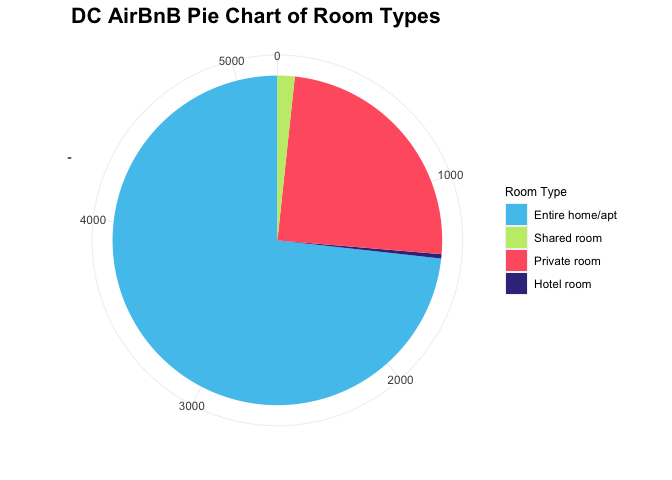

```r
d = as.data.frame(table(df$room_type))

group.colors = c("Entire home/apt" ="#51c5ed","Shared room"="#C3EB78","Private room"="#ff616f","Hotel room"="#3D348B")

ggplot(d, aes(y = Freq, x = "", fill = Var1)) + geom_bar(width=3, stat = "identity")+ coord_polar("y", start = 0)  + labs(title = "DC AirBnB Pie Chart of Room Types", x = "", y = "")+ theme(
        legend.title=element_text(size=9),
        plot.title = element_text(color="black", face="bold", size=16, hjust=0),
        panel.grid.major = element_line(colour = "grey90", size = 0.2),
        panel.grid.minor = element_blank(),
        panel.background = element_rect(fill = 'white'),legend.position="right")+
        scale_fill_manual(values=group.colors)+
        labs(fill = "Room Type", )
```

## Frequency of AirBnBs in Neighorhood by Room Type

We will now split this out by neighborhood to see where there is the greatest selection of AirBnB units in the district.

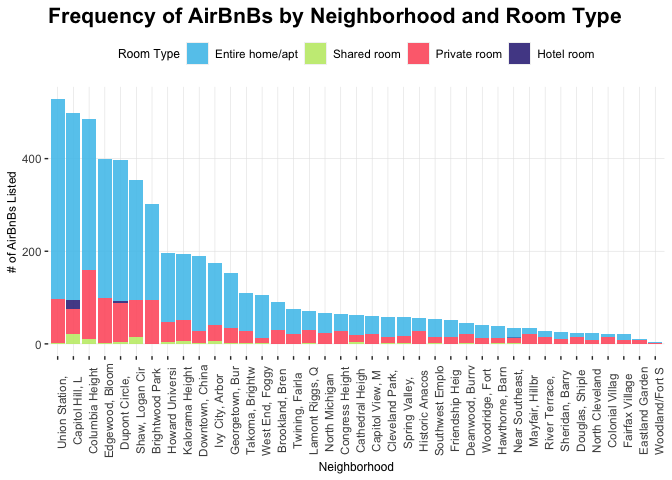

```r
#create column for neighborhood name in visualizations
df$neighbourhood_short <- str_sub(df$neighbourhood,1,15)

#add in column for frequency of listings
df_freq <- merge(df, data.frame(table(neighbourhood = df$neighbourhood)), by = c("neighbourhood"))


#create barplot of airbnb frequency by DC neighborhoods
ggplot(df_freq,aes(x=reorder(neighbourhood_short, neighbourhood_short, function(x)-length(x))))+geom_bar(aes(fill = room_type), alpha=.9)+ theme(axis.text.x = element_text(angle = 90),
        axis.title.x = element_text(size = 9),
        axis.title.y = element_text(size = 9),
        legend.title=element_text(size=9),
        plot.title = element_text(color="black", face="bold", size=16, hjust=0),
        panel.grid.major = element_line(colour = "grey90", size = 0.2),
        panel.grid.minor = element_blank(),
        panel.background = element_rect(fill = 'white'),legend.position="top")+
        scale_fill_manual(values=group.colors)+
        labs(fill = "Room Type", x="Neighborhood", y="# of AirBnBs Listed")+
        ggtitle("Frequency of AirBnBs by Neighborhood and Room Type")
```

```r
#v = as.data.frame(table(df$neighbourhood))
#v1 = v %>% slice(1:20)

#v2 = v %>% slice(21:50)

#par(mfrow = c(1,2))

#barplot(v1$Freq, main = "Barplot of Neighborhood Counts P1", ylab = "Count",  width = 5, names.arg = v1$Var1, las = 2, cex.names=0.6, col = 'darkred')

#barplot(v2$Freq, main = "Barplot of Neighborhood Counts P2", ylab = "Count",  width = 5, names.arg = v2$Var1, las = 2, cex.names=0.6, col = 'lightblue')
```

## Average price by room type

We are not sure what room type our friend is looking for. So, to allow them to understand the options, we will plot average price by room type. As we saw in the summary statistics, there is a large spread on this data. So, we will be viewing these plots zoomed in to the 0 - 95th percentile.

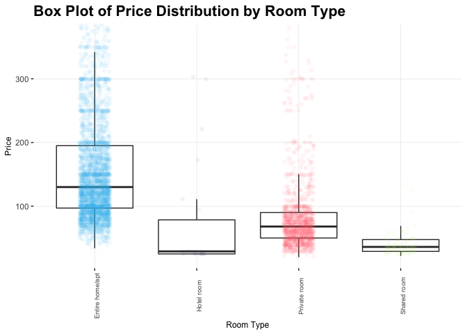

```r
ggplot(df,aes(x=room_type, y=price))+ geom_boxplot(outlier.shape = NA ) +
coord_cartesian(ylim = quantile(df$price, c(0.0, .95)))+
  geom_jitter(width=0.15, alpha=.05, aes(colour=room_type))+
  theme(axis.text.x = element_text(angle = 90, size=7))+
  theme(axis.text.x = element_text(angle = 90),
        axis.title.x = element_text(size = 9),
        axis.title.y = element_text(size = 9),

        plot.title = element_text(color="black", face="bold", size=16, hjust=0),
        panel.grid.major = element_line(colour = "grey90", size = 0.2),
        panel.grid.minor = element_blank(),
        panel.background = element_rect(fill = 'white'),
        legend.position = "none")+
        scale_colour_manual(values=group.colors)+
        labs( x="Room Type", y="Price")+
        ggtitle("Box Plot of Price Distribution by Room Type")
```

## Average review rating by room type

Now we will do the same for rating. This time we will zoom from the 1st to 100th percentile.

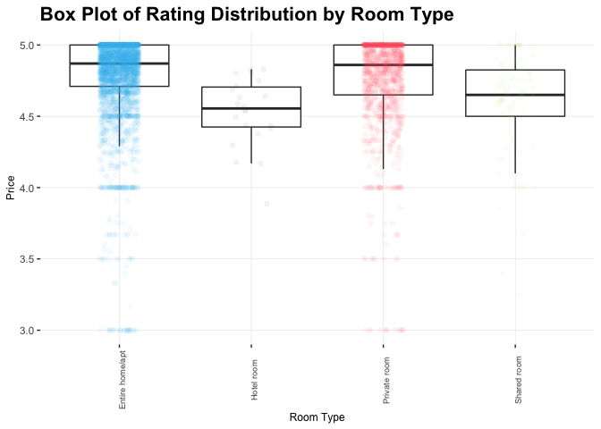

```r
ggplot(df,aes(x=room_type, y=review_scores_rating))+ geom_boxplot(outlier.shape = NA ) +
coord_cartesian(ylim = quantile(df$review_scores_rating, c(.01, 1)))+
  geom_jitter(width=0.15, alpha=.05, aes(colour=room_type))+
  theme(axis.text.x = element_text(angle = 90, size=7))+
  theme(axis.text.x = element_text(angle = 90),
        axis.title.x = element_text(size = 9),
        axis.title.y = element_text(size = 9),

        plot.title = element_text(color="black", face="bold", size=16, hjust=0),
        panel.grid.major = element_line(colour = "grey90", size = 0.2),
        panel.grid.minor = element_blank(),
        panel.background = element_rect(fill = 'white'),
        legend.position = "none")+
        scale_colour_manual(values=group.colors)+
        labs( x="Room Type", y="Price")+
        ggtitle("Box Plot of Rating Distribution by Room Type")
```

## Average amenities by room type

```r
price_room = df %>%
  group_by(room_type) %>%
  summarise_at(vars(price), list(price = mean))

price_room = data.frame(price_room)

price_room[order(-rank(price_room$price), decreasing = FALSE), ]%>%
  kbl() %>%
  kable_paper("hover", full_width = F)
```

|  | room_type | price |
| --- | --- | --- |
| 1 | Entire home/apt | 188.17388 |
| 3 | Private room | 89.65472 |
| 2 | Hotel room | 74.09091 |
| 4 | Shared room | 41.35227 |

```r
rating_room = df %>%
  group_by(room_type) %>%
  summarise_at(vars(review_scores_rating), list(review_scores_rating = mean))

rating_room = data.frame(rating_room)
rating_room[order(-rank(rating_room$review_scores_rating), decreasing = FALSE), ]%>%
  kbl() %>%
  kable_paper("hover", full_width = F)
```

|  | room_type | review_scores_rating |
| --- | --- | --- |
| 1 | Entire home/apt | 4.768051 |
| 3 | Private room | 4.729992 |
| 2 | Hotel room | 4.529091 |
| 4 | Shared room | 4.518750 |

```r
amenities_room = df %>%
  group_by(room_type) %>%
  summarise_at(vars(amenities), list(amenities = mean))

amenities_room = data.frame(amenities_room)

amenities_room[order(-rank(amenities_room$amenities), decreasing = FALSE), ]%>%
  kbl() %>%
  kable_paper("hover", full_width = F)
```

|  | room_type | amenities |
| --- | --- | --- |
| 1 | Entire home/apt | 32.32284 |
| 3 | Private room | 25.82151 |
| 2 | Hotel room | 22.45455 |
| 4 | Shared room | 21.59091 |

## Average price by neighborhood

```r
#subset data where frequency is greater than 175
df_175 <-  df_freq[ which(df_freq$Freq>175), ]
```

Our subsetted data set now has 10 neighborhoods with 3543 data points to analyze.

We can now analyze price across neighborhoods. To better view this graph, we will be zooming in to view the 0th to 95th percentile.

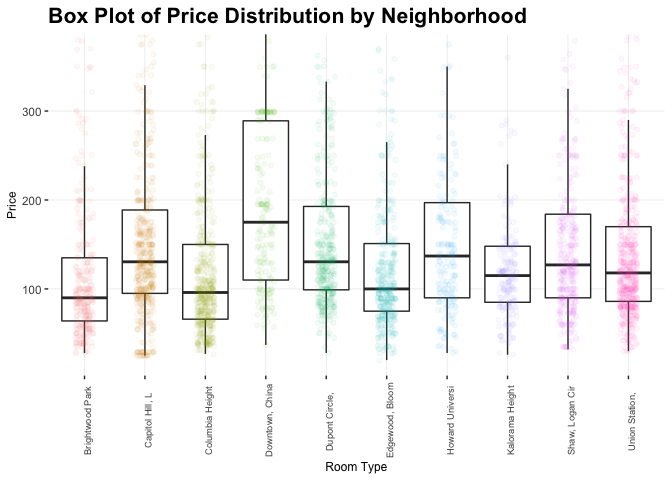

```r
ggplot(df_175,aes(x=neighbourhood_short, y=price))+ geom_boxplot(outlier.shape = NA ) +
coord_cartesian(ylim = quantile(df$price, c(.0, .95)))+
  geom_jitter(width=0.15, alpha=.05, aes(colour=neighbourhood_short))+
  theme(axis.text.x = element_text(angle = 90, size=7))+
  theme(axis.text.x = element_text(angle = 90),
        axis.title.x = element_text(size = 9),
        axis.title.y = element_text(size = 9),

        plot.title = element_text(color="black", face="bold", size=16, hjust=0),
        panel.grid.major = element_line(colour = "grey90", size = 0.2),
        panel.grid.minor = element_blank(),
        panel.background = element_rect(fill = 'white'),
        legend.position = "none")+
        labs( x="Room Type", y="Price")+
        ggtitle("Box Plot of Price Distribution by Neighborhood")
```

## Average review rating by neighborhood

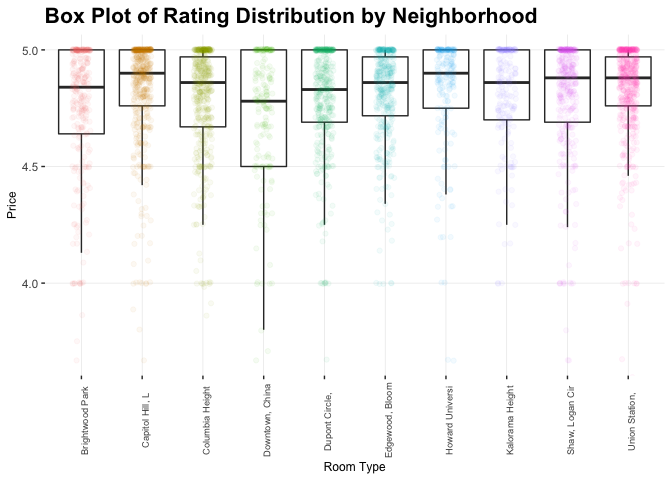

```r
ggplot(df_175,aes(x=neighbourhood_short, y=review_scores_rating))+ geom_boxplot(outlier.shape = NA ) +
coord_cartesian(ylim = quantile(df$review_scores_rating, c(.02, 1)))+
  geom_jitter(width=0.15, alpha=.05, aes(colour=neighbourhood_short))+
  theme(axis.text.x = element_text(angle = 90, size=7))+
  theme(axis.text.x = element_text(angle = 90),
        axis.title.x = element_text(size = 9),
        axis.title.y = element_text(size = 9),

        plot.title = element_text(color="black", face="bold", size=16, hjust=0),
        panel.grid.major = element_line(colour = "grey90", size = 0.2),
        panel.grid.minor = element_blank(),
        panel.background = element_rect(fill = 'white'),
        legend.position = "none")+
        labs( x="Room Type", y="Price")+
        ggtitle("Box Plot of Rating Distribution by Neighborhood")
```

## Average amenities by neighborhood

```r
price_neighbor = df_175 %>%
  group_by(neighbourhood) %>%
  summarise_at(vars(price), list(price = mean))

price_neighbor = data.frame(price_neighbor)

price_neighbor[order(-rank(price_neighbor$price), decreasing = FALSE), ]%>%
  kbl() %>%
  kable_paper("hover", full_width = F)
```

|  | neighbourhood | price |
| --- | --- | --- |
| 4 | Downtown, Chinatown, Penn Quarters, Mount Vernon Square, North Capitol Street | 199.3016 |
| 10 | Union Station, Stanton Park, Kingman Park | 178.7958 |
| 2 | Capitol Hill, Lincoln Park | 174.4880 |
| 9 | Shaw, Logan Circle | 171.1813 |
| 7 | Howard University, Le Droit Park, Cardozo/Shaw | 167.4061 |
| 5 | Dupont Circle, Connecticut Avenue/K Street | 165.7965 |
| 8 | Kalorama Heights, Adams Morgan, Lanier Heights | 144.2694 |
| 6 | Edgewood, Bloomingdale, Truxton Circle, Eckington | 139.0750 |
| 3 | Columbia Heights, Mt. Pleasant, Pleasant Plains, Park View | 126.2598 |
| 1 | Brightwood Park, Crestwood, Petworth | 123.0332 |

```r
rating_neighbor = df_175 %>%
  group_by(neighbourhood) %>%
  summarise_at(vars(review_scores_rating), list(review_scores_rating = mean))

rating_neighbor = data.frame(rating_neighbor)
#rating_neighbor
rating_neighbor[order(-rank(rating_neighbor$review_scores_rating), decreasing = FALSE), ]%>%
  kbl() %>%
  kable_paper("hover", full_width = F)
```

|  | neighbourhood | review_scores_rating |
| --- | --- | --- |
| 10 | Union Station, Stanton Park, Kingman Park | 4.823554 |
| 2 | Capitol Hill, Lincoln Park | 4.819237 |
| 7 | Howard University, Le Droit Park, Cardozo/Shaw | 4.785634 |
| 6 | Edgewood, Bloomingdale, Truxton Circle, Eckington | 4.777925 |
| 8 | Kalorama Heights, Adams Morgan, Lanier Heights | 4.753731 |
| 3 | Columbia Heights, Mt. Pleasant, Pleasant Plains, Park View | 4.752330 |
| 5 | Dupont Circle, Connecticut Avenue/K Street | 4.748744 |
| 9 | Shaw, Logan Circle | 4.731275 |
| 1 | Brightwood Park, Crestwood, Petworth | 4.704851 |
| 4 | Downtown, Chinatown, Penn Quarters, Mount Vernon Square, North Capitol Street | 4.622751 |

```r
amenities_neighborhood = df_175 %>%
  group_by(neighbourhood) %>%
  summarise_at(vars(amenities), list(amenities = mean))

amenities_neighborhood = data.frame(amenities_neighborhood)

amenities_neighborhood[order(-rank(amenities_neighborhood$amenities), decreasing = FALSE), ]%>%
  kbl() %>%
  kable_paper("hover", full_width = F)
```

|  | neighbourhood | amenities |
| --- | --- | --- |
| 2 | Capitol Hill, Lincoln Park | 32.09639 |
| 10 | Union Station, Stanton Park, Kingman Park | 31.23629 |
| 3 | Columbia Heights, Mt. Pleasant, Pleasant Plains, Park View | 30.56495 |
| 6 | Edgewood, Bloomingdale, Truxton Circle, Eckington | 30.56250 |
| 5 | Dupont Circle, Connecticut Avenue/K Street | 29.61055 |
| 9 | Shaw, Logan Circle | 29.55807 |
| 1 | Brightwood Park, Crestwood, Petworth | 29.54485 |
| 4 | Downtown, Chinatown, Penn Quarters, Mount Vernon Square, North Capitol Street | 29.32275 |
| 7 | Howard University, Le Droit Park, Cardozo/Shaw | 28.43655 |
| 8 | Kalorama Heights, Adams Morgan, Lanier Heights | 28.10881 |

## Histogram: Price, Number of Reviews, Amenities without Outliers

```r
Price_No_Outlier = outlierKD2(df, price, rm=TRUE)
```

```
## Outliers identified: 374
## Propotion (%) of outliers: 7.7
## Mean of the outliers: 672.12
## Mean without removing outliers: 160.93
## Mean if we remove outliers: 121.36
## Outliers successfully removed
```

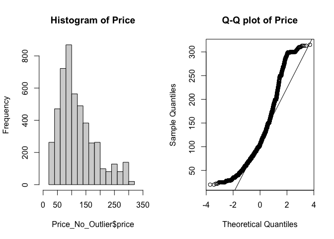

```r
par(mfrow = c(1,2))
hist(Price_No_Outlier$price, main = 'Histogram of Price', xlim = c(0,350))
qqnorm(Price_No_Outlier$price, main="Q-Q plot of Price")
qqline(Price_No_Outlier$price)
```

```r
Number_of_Reviews_No_Outlier = outlierKD2(df, number_of_reviews, rm=TRUE)
```

```
## Outliers identified: 461
## Propotion (%) of outliers: 9.7
## Mean of the outliers: 253.04
## Mean without removing outliers: 51.72
## Mean if we remove outliers: 32.16
## Outliers successfully removed
```

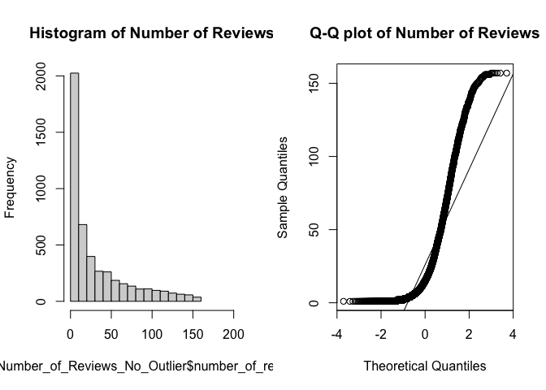

```r
par(mfrow = c(1,2))
hist(Number_of_Reviews_No_Outlier$number_of_reviews, main = 'Histogram of Number of Reviews', xlim = c(0,200))
qqnorm(Number_of_Reviews_No_Outlier$number_of_reviews, main="Q-Q plot of Number of Reviews")
qqline(Number_of_Reviews_No_Outlier$number_of_reviews)
```

```r
Number_of_Amenities_No_Outlier = outlierKD2(df, amenities, rm=TRUE)
```

```
## Outliers identified: 61
## Propotion (%) of outliers: 1.2
## Mean of the outliers: 63.87
## Mean without removing outliers: 30.5
## Mean if we remove outliers: 30.1
## Outliers successfully removed
```

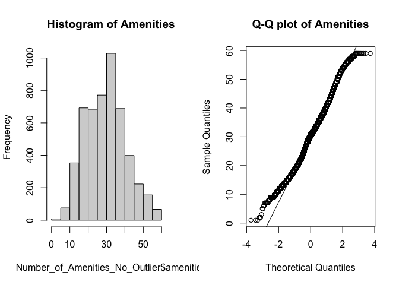

```r
par(mfrow = c(1,2))
hist(Number_of_Amenities_No_Outlier$amenities, main = 'Histogram of Amenities', xlim = c(0,65))
qqnorm(Number_of_Amenities_No_Outlier$amenities, main="Q-Q plot of Amenities")
qqline(Number_of_Amenities_No_Outlier$amenities)
```

## Compare Average Rank and Price Across Neighborhoods and Room_Type

To find the neighborhood that has the best AirBnB for rating and price, we will compare the mean price vs. mean rating for our 10 neighborhoods.

First, we will run an ANOVA to see if there is any significant difference between the price and rating averages across neighborhoods, then we will graph and select our best neighborhood selection.

```r
#anova test to compare mean price
anovaRes_price1 <-  aov(price ~ neighbourhood, data=df_175)
xkabledply(anovaRes_price1, title = "Price by Neighborhood ANOVA")
```

Price by Neighborhood ANOVA

|  | Df | Sum Sq | Mean Sq | F value | Pr(>F) |
| --- | --- | --- | --- | --- | --- |
| neighbourhood | 9 | 1825727 | 202858.61 | 3.2404 | 6e-04 |
| Residuals | 3533 | 221176255 | 62602.96 | NA | NA |

```r
#anova test to compare mean rating
anovaRes_rating1 <-  aov(review_scores_rating ~  neighbourhood, data=df_175)
xkabledply(anovaRes_rating1, title = "Rating by Neighborhood ANOVA")
```

Rating by Neighborhood ANOVA

|  | Df | Sum Sq | Mean Sq | F value | Pr(>F) |
| --- | --- | --- | --- | --- | --- |
| neighbourhood | 9 | 8.9461 | 0.994 | 6.8102 | 0 |
| Residuals | 3533 | 515.6780 | 0.146 | NA | NA |

What we find in both of these Anova results is that there is a significant difference between average price and rating by neighborhood. We will use this knowledge to assume there must be a DC neighborhood with the better prices/ratings than others.

```r
#create mean columns in dataframe

means_df <- df_175 %>%
  group_by(neighbourhood_short,neighbourhood) %>%
  summarise_at(vars(c(price,review_scores_rating, Freq, latitude,longitude)), funs(mean(., na.rm=TRUE)))
```

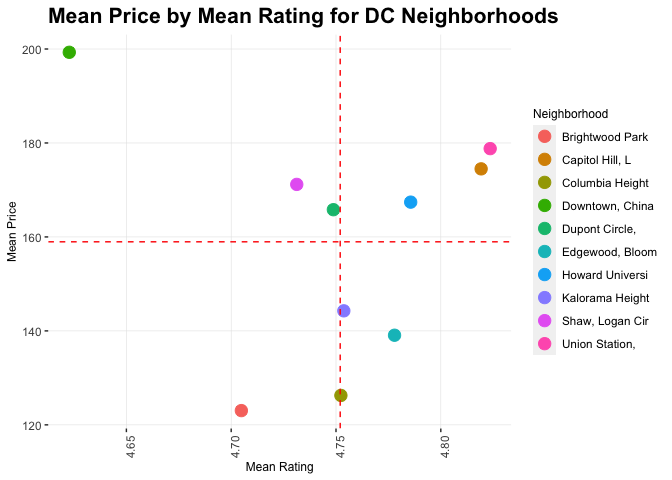

```r
means_df_rt <- df_175 %>%
  group_by(neighbourhood_short,neighbourhood,room_type) %>%
  summarise_at(vars(c(price,review_scores_rating, Freq, latitude,longitude)), funs(mean(., na.rm=TRUE)))

ggplot(means_df) + geom_point(aes(x=review_scores_rating, y=price, colour=neighbourhood_short),size=4)+ theme(axis.text.x = element_text(angle = 90),
        axis.title.x = element_text(size = 9),
        axis.title.y = element_text(size = 9),
        legend.title=element_text(size=9),
        plot.title = element_text(color="black", face="bold", size=16, hjust=0),
        panel.grid.major = element_line(colour = "grey90", size = 0.2),
        panel.grid.minor = element_blank(),
        panel.background = element_rect(fill = 'white'),
        legend.position="right")+
        labs(colour = "Neighborhood", x="Mean Rating", y="Mean Price")+
        ggtitle("Mean Price by Mean Rating for DC Neighborhoods")+ geom_hline(yintercept=mean(means_df$price), linetype="dashed", color = "red")+
   geom_vline(xintercept=mean(means_df$review_scores_rating), linetype="dashed", color = "red")
```

```r
means_df_select <- means_df[which(means_df$price<mean(means_df$price) & means_df$review_scores_rating > mean(means_df$review_scores_rating)),]

#id for neighborhoods
means_df_select$ID <- seq.int(nrow(means_df_select))

means_df_select[c(8,2:4)]%>%
  kbl() %>%
  kable_paper("hover", full_width = F)
```

| ID | neighbourhood | price | review_scores_rating |
| --- | --- | --- | --- |
| 1 | Columbia Heights, Mt. Pleasant, Pleasant Plains, Park View | 126.2598 | 4.752330 |
| 2 | Edgewood, Bloomingdale, Truxton Circle, Eckington | 139.0750 | 4.777925 |
| 3 | Kalorama Heights, Adams Morgan, Lanier Heights | 144.2694 | 4.753731 |

```r
pal1 <- colorFactor(c("#72B000","#00BFC4","#7997ff"), domain = c("Columbia Height", "Edgewood, Bloom", "Kalorama Height"))


# create leaflet map

map <- leaflet(means_df_select) %>%
  addTiles() %>%
  addCircleMarkers(lng = ~longitude,
                   lat = ~latitude,
                   radius=~sqrt(Freq),
                   color=~pal1(neighbourhood_short),
                   label=~ID,
                   labelOptions = labelOptions(noHide = T, textOnly = T, textsize = "7px",direction = 'center',style = list(
        "color" = "white")),
                   stroke = FALSE,
                   fillOpacity = 0.7)%>%
  addLegend("bottomright",pal = pal1, values = ~means_df_select$neighbourhood_short, opacity = 1, title = "Room Type")


map %>%  addProviderTiles(providers$CartoDB.Positron)
```

[interactive chart not shown]

This is helpful, but we should probably include room type to help our friend know if there is a room type/neighboorhood combination that would be the rest to search for.

Let’s run an anova to see if there is a significant difference between mean price and mean rating by room type.

```r
#anova test to compare mean price
anovaRes_price2 <-  aov(price ~ room_type, data=means_df_rt)
xkabledply(anovaRes_price2, title = "Price ANOVA")
```

Price ANOVA

|  | Df | Sum Sq | Mean Sq | F value | Pr(>F) |
| --- | --- | --- | --- | --- | --- |
| room_type | 3 | 83069.22 | 27689.742 | 22.3072 | 0 |
| Residuals | 27 | 33514.81 | 1241.289 | NA | NA |

```r
#anova test to compare mean rating
anovaRes_rating2 <-  aov(review_scores_rating ~ room_type, data=means_df_rt)
xkabledply(anovaRes_rating2, title = "Rating ANOVA")
```

Rating ANOVA

|  | Df | Sum Sq | Mean Sq | F value | Pr(>F) |
| --- | --- | --- | --- | --- | --- |
| room_type | 3 | 1.2857 | 0.4286 | 2.3062 | 0.0992 |
| Residuals | 27 | 5.0176 | 0.1858 | NA | NA |

What we find is that for price, room type is something to consider as there are significant differences between the mean prices. However, rating is not as much of a comparative factor when determining a room type to select on AirBnB as there is no significant differences between the mean.

We will show our friend an analysis where we look for the best true values by room type where the AirBnBs have a price lower than the mean and rating higher than the mean. However, rating should not be considered when choosing between different room types.

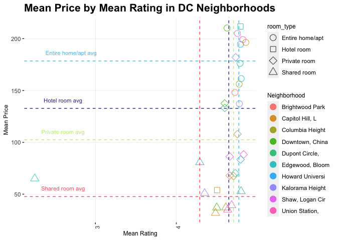

```r
means_df_rt_eha <- means_df_rt[which(means_df_rt$room_type=="Entire home/apt"),]

means_df_rt_pr <- means_df_rt[which(means_df_rt$room_type=="Private room"),]

means_df_rt_sr <- means_df_rt[which(means_df_rt$room_type=="Shared room"),]

means_df_rt_hr <- means_df_rt[which(means_df_rt$room_type=="Hotel room"),]


ggplot(means_df_rt) + geom_point(aes(x=review_scores_rating, y=price, colour=neighbourhood_short, shape=room_type),size=4, alpha=.85)+  scale_shape_manual(values=c(21,22,23,24))+
  theme(axis.text.x = element_text(angle = 90),
        axis.title.x = element_text(size = 9),
        axis.title.y = element_text(size = 9),
        legend.title=element_text(size=9),
        plot.title = element_text(color="black", face="bold", size=16, hjust=0),
        panel.grid.major = element_line(colour = "grey90", size = 0.2),
        panel.grid.minor = element_blank(),
        panel.background = element_rect(fill = 'white'),
        legend.position="right")+
        labs(colour = "Neighborhood", x="Mean Rating", y="Mean Price")+
        ggtitle("Mean Price by Mean Rating in DC Neighborhoods")+ geom_hline(yintercept=mean(means_df_rt_eha$price), linetype="dashed", color = "#51c5ed")+
        annotate("text", x=2.7, y=(mean(means_df_rt_eha$price)+8), label="Entire home/apt avg", color = "#51c5ed",size=3)+
        geom_vline(xintercept=mean(means_df_rt_eha$review_scores_rating), linetype="dashed", color = "#51c5ed")+
        geom_hline(yintercept=mean(means_df_rt_pr$price), linetype="dashed", color = "#C3EB78")+
        annotate("text", x=2.6, y=(mean(means_df_rt_pr$price)+8), label="Private room avg", color = "#C3EB78",size=3)+
        geom_vline(xintercept=mean(means_df_rt_pr$review_scores_rating), linetype="dashed", color = "#C3EB78")+
        geom_hline(yintercept=mean(means_df_rt_sr$price), linetype="dashed", color = "#ff616f")+
        annotate("text", x=2.6, y=(mean(means_df_rt_sr$price)+8), label="Shared room avg", color = "#ff616f",size=3)+
        geom_vline(xintercept=mean(means_df_rt_sr$review_scores_rating), linetype="dashed", color = "#ff616f")+
        geom_hline(yintercept=mean(means_df_rt_hr$price), linetype="dashed", color = "#3D348B")+
        annotate("text", x=2.6, y=(mean(means_df_rt_hr$price)+8), label="Hotel room avg", color = "#3D348B",size=3)+
        geom_vline(xintercept=mean(means_df_rt_hr$review_scores_rating), linetype="dashed", color = "#3D348B")
```

```r
means_df_rt_eha_select <- means_df_rt_eha[which(means_df_rt_eha$price<mean(means_df_rt_eha$price) & means_df_rt_eha$review_scores_rating > mean(means_df_rt_eha$review_scores_rating)),]

means_df_rt_pr_select <- means_df_rt_pr[which(means_df_rt_pr$price<mean(means_df_rt_pr$price) & means_df_rt_pr$review_scores_rating > mean(means_df_rt_pr$review_scores_rating)),]

means_df_rt_sr_select <- means_df_rt_sr[which(means_df_rt_sr$price<mean(means_df_rt_sr$price) & means_df_rt_sr$review_scores_rating > mean(means_df_rt_sr$review_scores_rating)),]

means_df_rt_hr_select <- means_df_rt_hr[which(means_df_rt_hr$price<mean(means_df_rt_hr$price) & means_df_rt_hr$review_scores_rating > mean(means_df_rt_hr$review_scores_rating)),]

means_df_rt_select <- rbind(means_df_rt_eha_select,means_df_rt_pr_select,means_df_rt_sr_select,means_df_rt_hr_select)
```

```r
#id for neighborhoods
means_df_rt_select$ID <- seq.int(nrow(means_df_rt_select))

means_df_rt_select[c(9,2:5)]%>%
  kbl() %>%
  kable_paper("hover", full_width = F)
```

| ID | neighbourhood | room_type | price | review_scores_rating |
| --- | --- | --- | --- | --- |
| 1 | Columbia Heights, Mt. Pleasant, Pleasant Plains, Park View | Entire home/apt | 156.20615 | 4.777846 |
| 2 | Dupont Circle, Connecticut Avenue/K Street | Entire home/apt | 176.14706 | 4.788464 |
| 3 | Edgewood, Bloomingdale, Truxton Circle, Eckington | Entire home/apt | 161.41722 | 4.802252 |
| 4 | Kalorama Heights, Adams Morgan, Lanier Heights | Entire home/apt | 137.19718 | 4.779718 |
| 5 | Edgewood, Bloomingdale, Truxton Circle, Eckington | Private room | 70.27835 | 4.728247 |
| 6 | Howard University, Le Droit Park, Cardozo/Shaw | Private room | 83.44444 | 4.794889 |
| 7 | Union Station, Stanton Park, Kingman Park | Private room | 88.32979 | 4.832234 |
| 8 | Capitol Hill, Lincoln Park | Shared room | 31.76190 | 4.484762 |
| 9 | Columbia Heights, Mt. Pleasant, Pleasant Plains, Park View | Shared room | 37.09091 | 4.612727 |
| 10 | Downtown, Chinatown, Penn Quarters, Mount Vernon Square, North Capitol Street | Shared room | 37.00000 | 4.500000 |
| 11 | Shaw, Logan Circle | Shared room | 39.21429 | 4.684286 |
| 12 | Union Station, Stanton Park, Kingman Park | Shared room | 35.00000 | 4.635000 |

Now we can map by room type suggestions

```r
#color palette

pal2 <- colorFactor(c("#51c5ed","#C3EB78","#ff616f","#3D348B"), domain = c("Entire home/apt","Shared room","Private room","Hotel room"))




# create leaflet map

map2 <- leaflet(means_df_rt_select) %>%
  addTiles() %>%
  addCircleMarkers(lng = ~longitude,
                   lat = ~latitude,
                   radius=~sqrt(Freq),
                   color=~pal2(room_type),
                   label=~ID,
                   labelOptions = labelOptions(noHide = T, textOnly = T, textsize = "7px",direction = 'center',style = list(
        "color" = "white")),
                   stroke = FALSE,
                   fillOpacity = 0.6)%>%
addLegend("bottomright",pal = pal2, values = ~means_df_rt_select$room_type, opacity = 1, title = "Room Type")

map2 %>%  addProviderTiles(providers$CartoDB.Positron)
```

[interactive chart not shown]

## Do names of listings affect reviews and price?

All listings try to keep catchy and attractive names to get clicks by prospective guests. We want to investigate whether names with certain characteristics are better or worse than others.

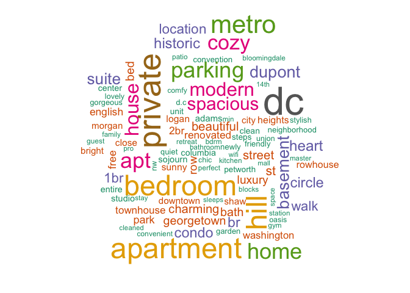

```r
data(stop_words)

corpus <- df %>% select(id, name) %>%
  unnest_tokens(word, name) %>% filter(!word %in% stop_words$word, str_detect(word, "[a-z]"))

all_words <- corpus %>% group_by(word) %>% dplyr::summarise(count = n())

wordcloud(words = all_words$word, freq = all_words$count, , min.freq = 50, colors=brewer.pal(8, "Dark2"))
```

The wordcloud shows that certain key words such as metro, basement, private, townhouse, metro etc are present in a lot of listings.

```r
df_corpus <- corpus %>% left_join(df)
```

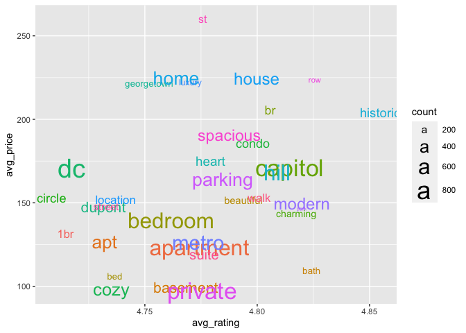

```r
corpus_agg <- df_corpus %>%
  group_by(word) %>%
  dplyr::summarise(avg_rating = mean(review_scores_rating), avg_price = mean(price), count = n()) %>%
  filter(count > 150)

ggplot(corpus_agg, aes(x=avg_rating, y=avg_price)) + geom_text(label=corpus_agg$word, aes(size=count, color = word)) + scale_size_continuous(range = c(2, 10)) + guides(color=FALSE)
```

- Cozy places are cheaper but worse than spacious ones.
- Houses are pricier than condos with no difference in ratings.
- Parking places are more expensive than those near a metro, with no difference in ratings.
- Historic places are the best rated.